# Midterm

Aileen Charron

2024-11-14

# 1. Data Wrangling

## 1.1 Download the data file

## 1.2 Read the dataset

```r
#import libraries
library(haven)
library(tidyverse)
library(VIM)
library(dplyr)
library(lubridate)
library(caret)
library(rpart)
library(rattle)
library(mlbench)
library(gridExtra)
library(ggthemes)
library(gganimate)
library(gifski)
library(knitr)
library(gapminder)
library(VIM)
```

```r
#read data
df = read_sas("C:\\Users\\student\\Documents\\M461-Statistical-Analysis-with-R\\hdd0318cy.sas7bdat")
```

## 1.3 Filter the data to have only patients of the year 2018 (yod = 18)

```r
#filter year to 2018
df <- df %>%
  filter(yod == 18)
```

## 1.4 Select to work with only following variables

```r
#select variables
df <- df %>%
  select("yod", "payfix","pay_ub92","age",
                      "sex","raceethn","provider","moa",
                      "yoa","mod","admtype", "asource" ,
                      "preopday" ,"los", "service" , "icu","ccu",
                      "dispub92", "payer"  ,"drg","trandb",
                      "randbg","randbs","orr", "anes","seq",
                      "lab","dtest", "ther","blood","phar",
                      "other","patcon","bwght","total","tot" ,
                      "ecodub92","b_wt","pt_state","diag_adm","ancilar" ,
                      "campus","er_fee","er_chrg","er_mode","obs_chrg",
                      "obs_hour","psycchrg","nicu_day")
```

## 1.5 What variables that have missing values?

```r
df <- read.csv("C:\\Users\\student\\Documents\\M461-Statistical-Analysis-with-R\\midtermdata.csv")
#determining missing values
colSums(is.na(df))
```

```
##      yod   payfix pay_ub92      age      sex raceethn provider      moa
##        0   131478        0        0        0     3950        0        0
##      yoa      mod  admtype  asource preopday      los  service      icu
##        0        0        1        0    60486        0        0        0
##      ccu dispub92    payer      drg   trandb   randbg   randbs      orr
##        0        0        0        0        0        0        0        0
##     anes      seq      lab    dtest     ther    blood     phar    other
##        0        0        0        0        0        0        0        0
##   patcon    bwght    total      tot ecodub92     b_wt pt_state diag_adm
##        0   131478        0        0        0        0        0        0
##  ancilar   campus   er_fee  er_chrg  er_mode obs_chrg obs_hour psycchrg
##        0        0        0        0    12158        0    77343        0
## nicu_day
##   124090
```

## 1.6 Remove all variables with missing values

```r
#removing variables with missing variables
df = df %>% select(-"payfix", -"preopday", -"obs_hour", -"nicu_day")
```

## 1.7 Which variable recording the month of admission? Which variable recording the month of discharge?

- moa: month of admission
- mod: month of discharge

```r
#creating month of admission variable with month names
df$moa_name <- case_when(
  df$moa  == 1 ~ "Jan",
  df$moa == 2 ~ "Feb",
  df$moa == 3 ~ "Mar",
  df$moa == 4 ~ "Apr",
  df$moa == 5 ~ "May",
  df$moa == 6 ~ "Jun",
  df$moa == 7 ~ "Jul",
  df$moa == 8 ~ "Aug",
  df$moa == 9 ~ "Sep",
  df$moa == 10 ~ "Oct",
  df$moa == 11~ "Nov",
  df$moa == 12 ~ "Dec")

df <- df %>%
  mutate(moa_name = factor(moa_name, levels = month.abb))
```

```r
#creating month of discharge variable with month names
df$mod_name <- case_when(
  df$mod  == 1 ~ "Jan",
  df$mod == 2 ~ "Feb",
  df$mod == 3 ~ "Mar",
  df$mod == 4 ~ "Apr",
  df$mod == 5 ~ "May",
  df$mod == 6 ~ "Jun",
  df$mod == 7 ~ "Jul",
  df$mod == 8 ~ "Aug",
  df$mod == 9 ~ "Sep",
  df$mod == 10 ~ "Oct",
  df$mod == 11~ "Nov",
  df$mod == 12 ~ "Dec")

df <- df %>%
  mutate(mod_name = factor(mod_name, levels = month.abb))
```

```r
#creating provider name varialbe
df$provider_name <- case_when(
  df$provider == 7201 ~ "Newport",
  df$provider == 7202 ~ "St. Joseph",
  df$provider == 7203 ~ "Memorial",
  df$provider == 7204 ~ "Miriam",
  df$provider == 7205 ~ "Rhode Island Hospital",
  df$provider == 7206 ~ "Roger Williams",
  df$provider == 7209 ~ "South County",
  df$provider == 7210 ~ "Kent County",
  df$provider == 7211 ~ "Westerly",
  df$provider == 7212 ~ "Rehab of RI",
  df$provider == 7213 ~ "Landmark Medical Center",
  df$provider == 7214 ~ "Women and infants",
  df$provider == 7215 ~ "Bradley",
  df$provider == 7216 ~ "Butler"

)
```

```r
#creating age group variable

df$age_group <- case_when(
  df$age <= 10 ~ "0-10",
  df$age <= 20 ~ "11-20",
  df$age <= 30 ~ "21-30",
  df$age <= 40 ~ "31-40",
  df$age <=50 ~"41-50",
  df$age <= 60 ~ "51 - 60",
  df$age <= 70 ~ "61 - 70",
  df$age <= 80 ~ "71 - 80",
  df$age <= 90 ~ "81 - 90",
  df$age <= 100 ~ "91 - 100",
  df$age > 100 ~ "100+"
)
```

```r
#removing observations where sex = 9
df <- df %>% filter(sex != 9)
```

```r
#creating a sex name variable

df$sex_name <- case_when(
  df$sex == 1 ~ "Male",
  df$sex == 2 ~ "Female")
```

```r
#creating variable that indicates 1 if in providence, 0 if not
df <- df %>%
  mutate(Providence = case_when(
    provider %in% c(7205, 7206, 7209, 7213, 7216) ~ 1,
    TRUE ~ 0
  ))
```

```r
#making Providence as factor
df <- df %>%
  mutate(Providence = as.factor(Providence))
```

## 1.8 Which month admitted the most number of patients? Which month admitted the most number of male patients?

```r
#month with most admitted patients
df %>% group_by(moa_name) %>%
  summarize(total_admissions = n()) %>%
  arrange(desc(total_admissions))
```

```
## # A tibble: 12 × 2
##    moa_name total_admissions
##    <fct>               <int>
##  1 Oct                 11407
##  2 May                 11403
##  3 Jan                 11309
##  4 Aug                 11199
##  5 Apr                 11174
##  6 Mar                 11072
##  7 Jul                 10962
##  8 Dec                 10697
##  9 Jun                 10690
## 10 Sep                 10666
## 11 Nov                 10636
## 12 Feb                 10259
```

October admitted the most patients

```r
#month with most admitted male patientw
df %>%  filter(sex == 1) %>%
  group_by(moa_name) %>%
  summarize(total_admissions = n()) %>%
  arrange(desc(total_admissions))
```

```
## # A tibble: 12 × 2
##    moa_name total_admissions
##    <fct>               <int>
##  1 Oct                  5164
##  2 May                  5066
##  3 Aug                  5028
##  4 Apr                  4989
##  5 Mar                  4978
##  6 Jan                  4970
##  7 Jul                  4910
##  8 Dec                  4855
##  9 Jun                  4810
## 10 Nov                  4800
## 11 Sep                  4683
## 12 Feb                  4546
```

October admitted the most male patients

## 1.9 Which month has the most number of teenage female patients?

```r
#month with most teenage female patients
df %>% filter(sex == 2) %>%
filter(age >= 13) %>%
  filter(age <=19) %>%
  group_by(moa_name) %>%
  summarize(total_admissions = n()) %>%
  arrange(desc(total_admissions))
```

```
## # A tibble: 12 × 2
##    moa_name total_admissions
##    <fct>               <int>
##  1 Mar                   226
##  2 May                   220
##  3 Oct                   212
##  4 Dec                   208
##  5 Jan                   207
##  6 Sep                   196
##  7 Apr                   187
##  8 Nov                   177
##  9 Feb                   172
## 10 Aug                   172
## 11 Jul                   171
## 12 Jun                   169
```

March admitted the most teenage female patients

## 1.10 which provider has the most number of female patients in October?

```r
df %>% filter(sex == 2) %>%
  group_by(provider_name) %>%
  summarize(total_admissions = n()) %>%
  arrange(desc(total_admissions))
```

```
## # A tibble: 12 × 2
##    provider_name           total_admissions
##    <chr>                              <int>
##  1 Rhode Island Hospital              17795
##  2 Women and infants                  14616
##  3 Miriam                             10340
##  4 Kent County                         8371
##  5 South County                        3867
##  6 Landmark Medical Center             3560
##  7 Roger Williams                      3495
##  8 Newport                             3111
##  9 Butler                              2865
## 10 St. Joseph                          2715
## 11 Westerly                            1385
## 12 Bradley                              555
```

## 1.11 are female patients older than male patients, on average?

```r
df %>% group_by(sex_name) %>%
  summarize(average_age = mean(age)) %>%
  arrange(average_age)
```

```
## # A tibble: 2 × 2
##   sex_name average_age
##   <chr>          <dbl>
## 1 Female          50.9
## 2 Male            51.5
```

On average, males are older than females

## 1.12 calculate the average age of patients by month. which month has the oldest patients on average age?

```r
df %>% group_by(moa_name) %>%
  summarize(average_age = mean(age)) %>%
  arrange(desc(average_age))
```

```
## # A tibble: 12 × 2
##    moa_name average_age
##    <fct>          <dbl>
##  1 Jan             51.8
##  2 Jun             51.5
##  3 Dec             51.5
##  4 Apr             51.4
##  5 Jul             51.3
##  6 Feb             51.2
##  7 Mar             51.1
##  8 Nov             51.0
##  9 Aug             50.9
## 10 Oct             50.8
## 11 May             50.6
## 12 Sep             50.6
```

January has the oldest patients on average

## 1.13 what is the name of the provider that has the highest total charge?

```r
df %>% group_by(provider_name) %>%
  summarize(average_total_charge = mean(tot)) %>%
  arrange(desc(average_total_charge))
```

```
## # A tibble: 12 × 2
##    provider_name           average_total_charge
##    <chr>                                  <dbl>
##  1 Bradley                               69946.
##  2 Rhode Island Hospital                 48739.
##  3 Landmark Medical Center               38202.
##  4 St. Joseph                            35504.
##  5 Miriam                                35277.
##  6 Roger Williams                        31018.
##  7 Kent County                           27691.
##  8 South County                          24539.
##  9 Westerly                              24089.
## 10 Newport                               22775.
## 11 Women and infants                     22363.
## 12 Butler                                17784.
```

Bradley has the highest average total charge

## 1.14 what is the name of the provider that has the least total charge for teenage male on average

```r
df %>%
  filter(sex == 1) %>%
  filter(age >= 13 | age <=19) %>%
  group_by(provider_name) %>%
  summarize(average_total_charge = mean(tot)) %>%
  arrange(average_total_charge)
```

```
## # A tibble: 12 × 2
##    provider_name           average_total_charge
##    <chr>                                  <dbl>
##  1 Butler                                16606.
##  2 Newport                               23197.
##  3 Women and infants                     25295.
##  4 Westerly                              25629.
##  5 South County                          26509.
##  6 Kent County                           28307.
##  7 Roger Williams                        31549.
##  8 St. Joseph                            36122.
##  9 Miriam                                36296.
## 10 Landmark Medical Center               39733.
## 11 Rhode Island Hospital                 51022.
## 12 Bradley                               86740.
```

## 1.15 create a season (spring, summer, fall, winter) variable. calculate the length of the stays by season. which season has the longest of stays on average?

```r
df$season <- case_when(
  df$moa %in% c(7,8,9) ~ "summer",
  df$moa %in% c(10,11,12) ~ "fall",
  df$moa %in% c(1,2,3) ~ "winter",
  df$moa %in% c(4,5,6) ~ "spring")
```

```r
df %>%
  group_by(season) %>%
  summarize(average_los = mean(los)) %>%
  arrange(desc(average_los))
```

```
## # A tibble: 4 × 2
##   season average_los
##   <chr>        <dbl>
## 1 fall          4.99
## 2 summer        4.96
## 3 winter        4.88
## 4 spring        4.84
```

fall has the longest average length of stay on average

## 1.16 on average, how much do a 20 year old male get charged for staying 1 day in the Fall season?

```r
df %>%
  filter(age == 20) %>%
  filter(sex == 1) %>%
  filter(los == 1) %>%
  filter(season == "fall") %>%
  summarize(average_tot = mean(tot))
```

```
##   average_tot
## 1       16511
```

on average, a 20 year old male gets charged $16,511 for staying 1 day in the fall

## 1.17 write a paragraph to summarize the section and give your comments on the results. you could do some other calculations to support your points

The data definitely shows variation within the data when subsetted into different subcategories.

# 2. Data Visualization

## 2.1 provide at least 10 meaningful plots. comment on the plots. all plots should have title, caption, appropriate labels on x and y- axis

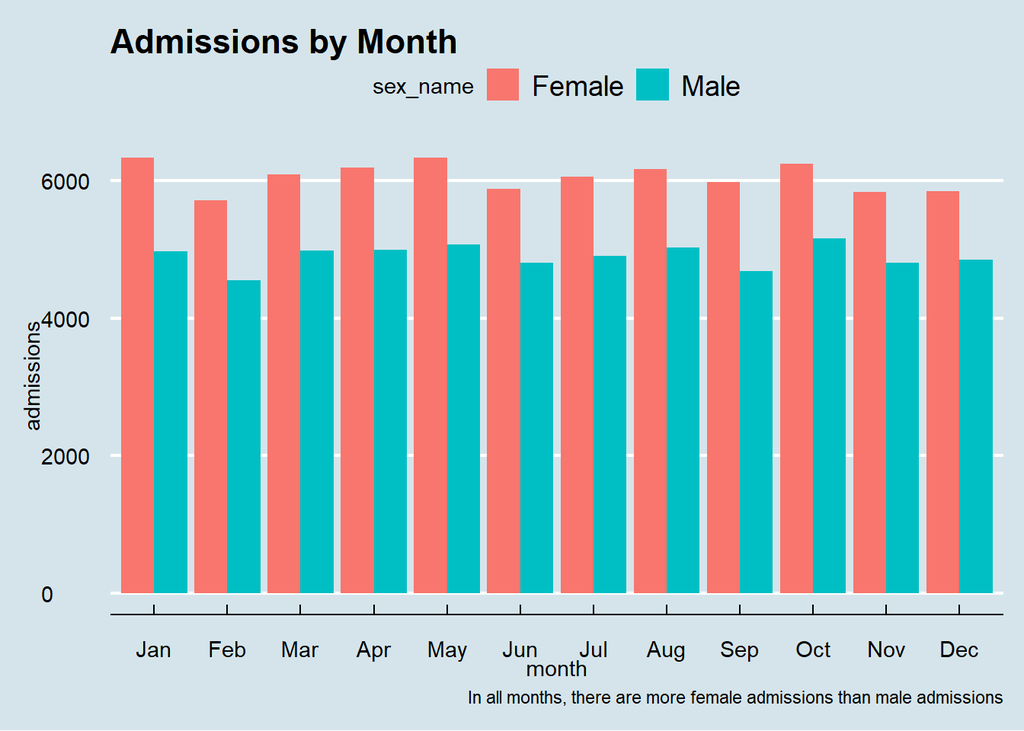

```r
#1
# looking at total admissions by month by gender
graph1 <- df %>% ggplot + geom_bar(mapping = aes(x = moa_name, fill = sex_name), position = 'dodge') +
  labs(
    title = "Admissions by Month",
    x = "month",
    y = "admissions",
    caption = "In all months, there are more female admissions than male admissions"
  ) + theme_economist()

ggsave(filename = 'graph1.png', plot = graph1)
graph1
```

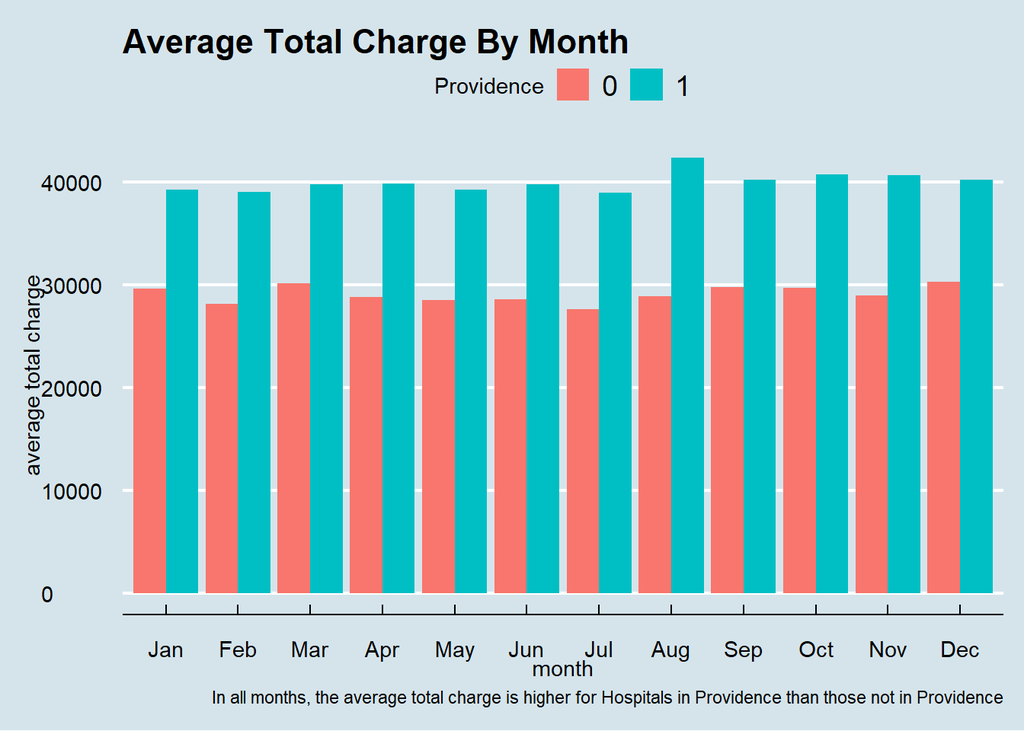

```r
#2
# looking at total charges by Providence or not
graph2 <- df %>% group_by(moa_name, Providence) %>%
  summarize(average_tot = mean(tot)) %>%
  ggplot +
  geom_col(mapping = aes(x = moa_name, y = average_tot, fill = Providence), position = 'dodge') +
  labs(
    title = "Average Total Charge By Month",
    x = "month",
    y = "average total charge",
    caption = "In all months, the average total charge is higher for Hospitals in Providence than those not in Providence"
  ) + theme_economist()
ggsave(filename = 'graph2.png', plot = graph2)
graph2
```

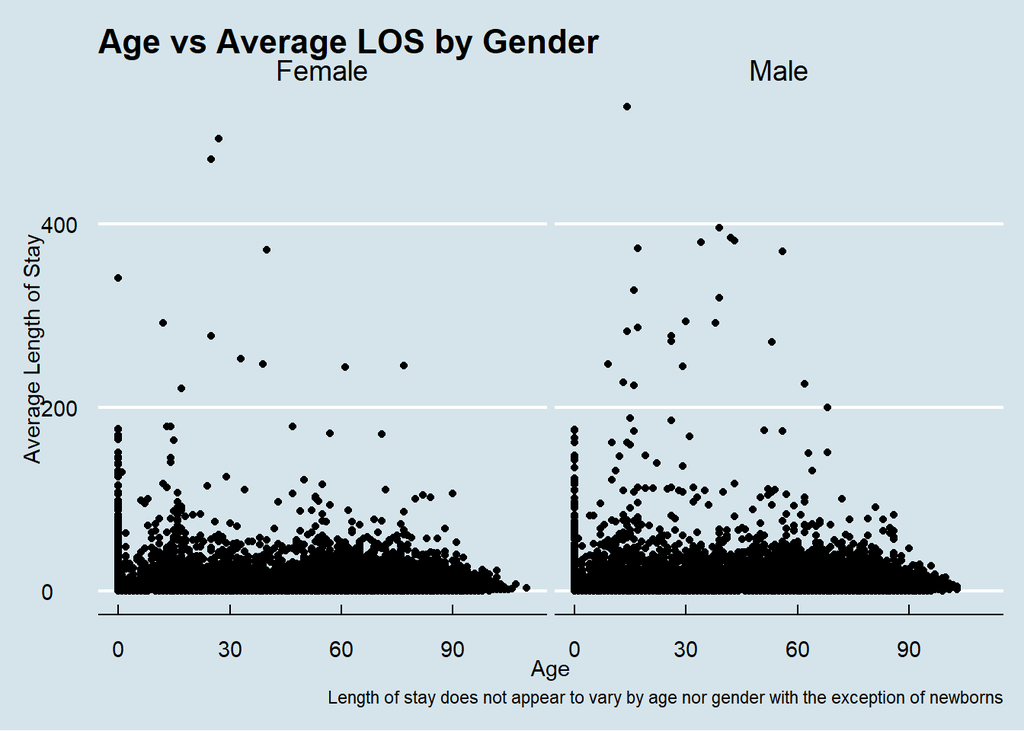

```r
#3
# looking at age vs LOS by gender
graph3 <- df %>% group_by(age, sex_name,los) %>%
  summarize(average_LOS = mean(los)) %>%
  ggplot(aes(x = age, y = average_LOS))+
  geom_point() +
  labs(
    title = "Age vs Average LOS by Gender",
    x = "Age",
    y = "Average Length of Stay",
    caption = "Length of stay does not appear to vary by age nor gender with the exception of newborns") +
  facet_wrap(~sex_name)+
  theme_economist()
ggsave(filename = 'graph3.png', plot = graph3)
graph3
```

```r
# 4
#looking at age vs avg total charge by gender
graph4 <-df %>% group_by(age, sex_name) %>%
  summarize(average_tot = mean(tot)) %>%
  ggplot(aes(x = age, y = average_tot, color = sex_name))+
  geom_point() +
  labs(
    title = "Age vs Average total charge by Gender",
    x = "Age",
    y = "Average total charge",
    caption = "appears to have a dip aorund age 30 for both male and females, females tend to be slightly lower charges") +
  theme_economist()
```

[output not shown]

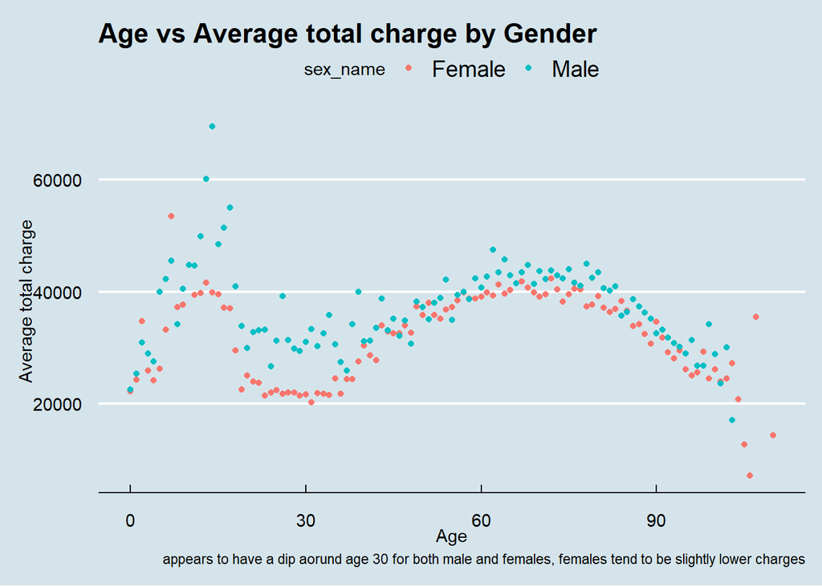

```r
ggsave(filename = 'graph4.png', plot = graph4)
graph4
```

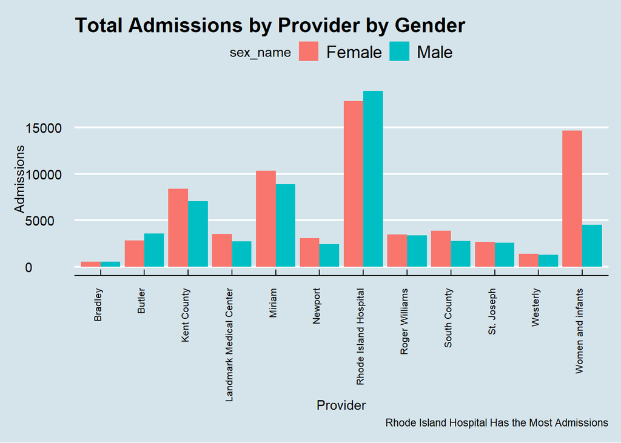

```r
# 5 looking at total admissions by provider by gender
graph5 <- df %>% group_by(provider_name, sex_name) %>%
  ggplot +
  geom_bar(mapping = aes(x = provider_name, fill = sex_name), position = 'dodge') +
  labs(
    title = "Total Admissions by Provider by Gender",
    x = "Provider",
    y = "Admissions",
    caption = "Rhode Island Hospital Has the Most Admissions"
  ) + theme_economist() +
  theme(
    axis.text.x = element_text(angle = 90, hjust = 1, size = 8)
  )
ggsave(filename = 'graph5.png', plot = graph5)
graph5
```

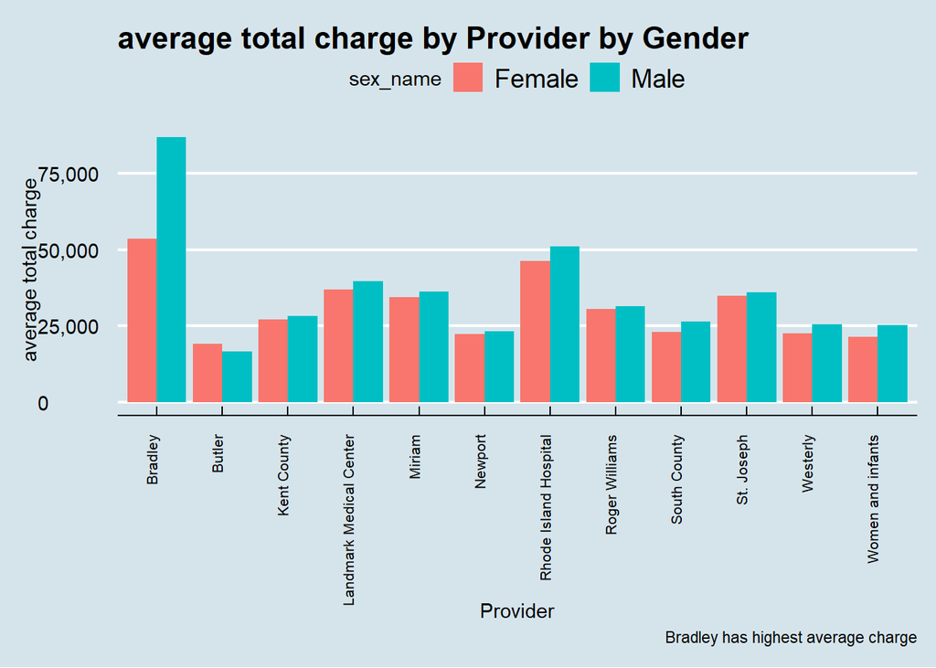

```r
# 6
#looking at average total charge by provider by gender
graph6 <-df %>% group_by(provider_name, sex_name) %>%
  summarize(average_total_charge = mean(tot)) %>%
  ggplot +
  geom_col(mapping = aes(x = provider_name, y = average_total_charge, fill = sex_name), position = "dodge") +
  labs(
    title = "average total charge by Provider by Gender",
    x = "Provider",
    y = "average total charge",
    caption = "Bradley has highest average charge") + theme_economist() +
  theme(
    axis.text.x = element_text(angle = 90, hjust = 1, size = 8)) +
      scale_y_continuous(labels = scales::comma)
graph6
```